# deep_learning_project

[figure not shown]

```python
#----- import libraries utils for the project---------
import numpy as np
import pandas as pd
import matplotlib.pyplot as plt
from random import seed
from random import random
import random
from shutil import copyfile
from os import makedirs, listdir
import sys
from matplotlib.image import imread

import shutil
import tensorflow as tf
from tensorflow import keras
import keras
import tensorflow.keras as keras
from tensorflow.keras import layers
from keras.models import Sequential
from keras.layers import Conv2D, MaxPooling2D, Dropout,\
Flatten, Dense, Activation, BatchNormalization
from keras.preprocessing.image import ImageDataGenerator, load_img, img_to_array
#from wand.image import Image as WImage
%matplotlib inline

# cufflinks and plotly  interactive vizualization libraries

import cufflinks as cf
import plotly.graph_objs as go
import plotly.offline as py
import plotly.express as px
from plotly.offline import download_plotlyjs, init_notebook_mode, plot, iplot
init_notebook_mode(connected= True)
cf.go_offline()
```

```python
#!pip install plotly
#!pip install cufflinks
#!pip install Wand
```

### Constants usefull

```python
#---------  Directories  -------------
cat_dog_src_dirct =  "/data/dataset/"  # raw data directory
```

### Exploratory Data Analyis (EDA)

Performing some EDA on *Cat* vs *Dog* raw data.With the objective to figure out how the images look like

```python
#check the number of files in raw data
nb_images = len(listdir(cat_dog_src_dirct)) # the number of files in data source directory
nb_images
```

```
3000
```

### Plot few images from raw data

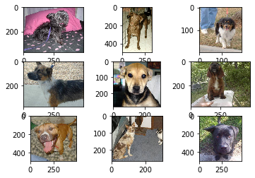

```python
 # The following for loop will find the first 9 dog picutes from the directory and show them in 3x3
nrows = 3
ncols = 3
for i in range(9):
    plt.subplot(nrows,ncols,0 + 1 + i)
    img = cat_dog_src_dirct + 'dog.' + str(i) + '.jpg'
    img = imread(img)
    plt.imshow(img)
plt.show()
```

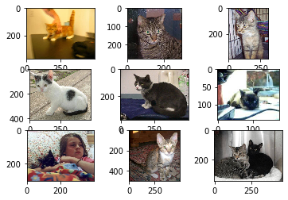

```python
# As in the previous lines of code, the following code will show the first cat images from the dataset.
nrows = 3
ncols = 3
for i in range(9):
    plt.subplot(nrows,ncols,0 + 1 + i)
    img = cat_dog_src_dirct + 'cat.' + str(i) + '.jpg'
    img = imread(img)
    plt.imshow(img)
plt.show()
```

# Tasks

## Task 1 - Dataset

In the below few lines of code, a function implementing data splitting into a list of directories containing; **train, test, validation** is performed. For each of the directories, two subdirectories named **cats** and **dogs** are created. Accordingly, to an appropriate splitting ratio, the cats and dogs will go to the subdirectories with the same name. In this case, 80% of the data will go to **train** folder. The **test** and **validation** will contain 10% of data each.

```python
def train_test_val_split(src_dir, dataset_home, train_size = 0.80):
    '''
    This function   will take the source and destination directory paths with an optional  training size.
    The data from source directory is split into train, test and validation folders.
    For each of these folders two subdirectories named cats and dogs are created.
    These two subdirectories will contain the images with the same name.

    Parameters
    ----------
        src_dir : source directory
        data_home : destination directory
        train_size : default 0.8
    Creates folders
    ---------------
        training, validation and test data are created

    '''

    split_dirs_list = ['train/', 'test/','validation/'] # list of folders

    for split_dir in split_dirs_list:
        # create dogs and cats subdirectories
        sub_dirs_list = ['dogs/', 'cats/']
        for sub_dir in  sub_dirs_list:
            dir_to_create = dataset_home + split_dir + sub_dir
            makedirs( dir_to_create , exist_ok=True)
    img_filenames =listdir(src_dir)

    random.seed(101)  # helpful for random shuffle
    random.shuffle(img_filenames) # random shuffle the files

    train_part = int(train_size * len(img_filenames)) # Partition used for training
    test_val_part = int(0.9 * len(img_filenames)) #used to assign 10% the rest of the data to the test and validatation each
    train_split = img_filenames[:train_part]   # train dataset
    val_split = img_filenames[train_part:test_val_part] #validation dataset
    test_split = img_filenames[test_val_part:]  # test dataset

    split_list = [test_split, train_split, val_split] # list containing train, test and validation split.

    for fl in split_list:
        if(fl == test_split):
            for img in fl:
                src = src_dir + '/' + img
                dst_dir = 'test/'
                if(img.startswith('cat')):
                    dst = dataset_home + dst_dir + 'cats/'+ img
                    copyfile(src, dst)
                else:
                    dst = dataset_home + dst_dir + 'dogs/'  + img
                    copyfile(src, dst)

        if(fl == train_split):
            for img in fl:
                src = src_dir + '/' + img
                dst_dir = 'train/'
                if(img.startswith('cat')):
                    dst = dataset_home + dst_dir + 'cats/'+ img
                    copyfile(src, dst)
                else:
                    dst = dataset_home + dst_dir + 'dogs/'  + img
                    copyfile(src, dst)

        if(fl == val_split):
            for img in fl:

                src = src_dir + '/' + img
                dst_dir = 'validation/'
                if(img.startswith('cat')):
                    dst = dataset_home + dst_dir + 'cats/'+ img
                    copyfile(src, dst)
                else:
                    dst = dataset_home + dst_dir + 'dogs/'  + img
                    copyfile(src, dst)

#--------------  call tgrain_test_val_split function ----------------------------------------- #

dataset_home = "/data_home/"
src_dir =  "/data/dataset" #  "/catdog_data/dataset"
train_test_val_split(src_dir,dataset_home)
```

## The Structure of Dataset

[figure not shown]

## Task 2 - Creating the datagenerators

```python
# Define Contstants helpful for the implementation
IMAGE_WIDTH = 200  # fixed image width
IMAGE_HEIGHT = 200  # fixed image height
IMAGE_SIZE = (IMAGE_WIDTH , IMAGE_HEIGHT) # iamge size
INPUT_SHAPE = (IMAGE_WIDTH, IMAGE_HEIGHT, 3) # input shape
IMAGE_CHANNELS = 3 # image channel
seed = random.seed(101) # random seed useful for random shuffiling and transformations
batch_size = 32  # batch size
## ----------------- Directory paths to save generated images -----------------------------------------
generated_training_images = "/generated_images/train" # directory path to save the generated training image
generated_test_images = "/generated_images/test" # path for generated test images
generated_validation_images = "/generated_images/validation" # path for the generated validation images
```

```python
# Creating an instance of ImageDataGeneration class using the data augmentation parameters for training data generation
train_datagen = ImageDataGenerator(
    rescale=1.0/255.0,
    shear_range= 0.0,
    width_shift_range= 0.0,
    height_shift_range= 0.0,
    zoom_range= 0.0,
    horizontal_flip= True
)
# Create an instance  of ImageDataGenerator for test data generation using rescale variable
test_datagen = ImageDataGenerator(
    rescale=1.0/255.0

)
# Create an instance  of ImageDataGenerator for validation data generation using rescale variable
val_datagen = ImageDataGenerator(
    rescale=1.0/255.0

)
```

### ImageDataGenerator: explained parameters

In the following few bulleted lines, the choosen parameters are explained:

- **rescale** : is to rescale the original image between 0 to 1 by multiply it with 1/255 factor
- **shear_range** : is for random shearing transformations
- **width_shift_range** and **height_shift_range** are ranges to translate vertically or horizontaly
- **zoom_range**: is for applying random zooming of pictures
- **horizontal_flip** : is for random flipping of image

```python
# prepare iterators
train_data = train_datagen.flow_from_directory(
    "/data_home/train", # path of training data directory'
    class_mode='binary', # needed for binary_crossentropy loss.
    batch_size= batch_size,  #  batch size
    target_size= IMAGE_SIZE, # fixed  images size
    #save_to_dir = generated_training_images,  #  path of generated raining  images
    shuffle= True,   # random shuffle of the images
    subset= 'training',
    seed = seed
)

test_data = test_datagen.flow_from_directory(
    dataset_home  +'test', # Directory of test data
    class_mode='binary', # binary class label
    batch_size=batch_size, # batch size
    #save_to_dir = generated_test_images, # directory of generated test images
    save_format='jpg', # image format
    target_size = IMAGE_SIZE, # desired image size
    shuffle= True,
    seed = seed
)
val_data = val_datagen.flow_from_directory(
     dataset_home  +'validation', #dataset_home  +'validation/',
    class_mode='binary',
    batch_size=batch_size,
    target_size=IMAGE_SIZE,
    #save_to_dir = generated_validation_images,
    shuffle= True,
    seed = seed
)
```

```
Found 2400 images belonging to 2 classes.
Found 300 images belonging to 2 classes.
Found 300 images belonging to 2 classes.
```

## Task 3 - Constructing the network

Having prepared the data and made the generators, It is time to build the model or network, in order to fit and train it on the dataset with the appropriate architectures and parameters. As any machine learning problem, the most accurate result can only be achieved by choosing a good data quality and the optimal parameter combination. To achieve the best accuracy, range of models have to be investigated.

Designing the CNN architecture in Keras is a matter of instantiating an object **Sequential** class or constructor, then a model is built by stacking a block of layers. In this project, the study has chosen to start by a convolutional layer with 3x3 filters, follows by Maxpooling layers with 2x2 filters and an appropriate activation parameter, *relu* in the case. The process has been repeated gradually by increased network depth, to perform different models and comparative study among them with the ultimate of finding the most accurate.

## Model 1

```python
model = Sequential() # call an empty constructor of Sequential class.
## Add Block 1 --------
model.add(layers.Conv2D(32, (3, 3), input_shape=(IMAGE_WIDTH, IMAGE_HEIGHT, 3), padding = 'same'))
model.add(layers.Activation('relu'))
model.add(layers.MaxPooling2D(pool_size=(2, 2)))

## Add block 2
model.add(layers.Conv2D(32, (3, 3)))
model.add(layers.Activation('relu'))
model.add(layers.MaxPooling2D(pool_size=(2, 2)))
## Add block 3
model.add(layers.Conv2D(64, (3, 3)))
model.add(layers.Activation('relu'))
model.add(layers.MaxPooling2D(pool_size=(2, 2)))

# Add  block 3
model.add(Conv2D(128, (3, 3)))
model.add(Conv2D(128, (3, 3)))
model.add(Activation('relu'))
model.add(MaxPooling2D(pool_size=(2, 2)))

# Add block 4
model.add(layers.Flatten())
model.add(layers.Dense(128))
model.add(layers.Activation('relu'))
model.add(layers.Dropout(0.5))
model.add(layers.Dense(1))
model.add(layers.Activation('sigmoid'))

model.compile(loss='binary_crossentropy',
              optimizer='rmsprop',
              metrics=['accuracy'])
```

```python
model.summary()
```

```
Model: "sequential_4"
_________________________________________________________________
Layer (type)                 Output Shape              Param #
=================================================================
conv2d_24 (Conv2D)           (None, 200, 200, 32)      896
_________________________________________________________________
activation_22 (Activation)   (None, 200, 200, 32)      0
_________________________________________________________________
max_pooling2d_18 (MaxPooling (None, 100, 100, 32)      0
_________________________________________________________________
conv2d_25 (Conv2D)           (None, 98, 98, 32)        9248
_________________________________________________________________
activation_23 (Activation)   (None, 98, 98, 32)        0
_________________________________________________________________
max_pooling2d_19 (MaxPooling (None, 49, 49, 32)        0
_________________________________________________________________
conv2d_26 (Conv2D)           (None, 47, 47, 64)        18496
_________________________________________________________________
activation_24 (Activation)   (None, 47, 47, 64)        0
_________________________________________________________________
max_pooling2d_20 (MaxPooling (None, 23, 23, 64)        0
_________________________________________________________________
conv2d_27 (Conv2D)           (None, 21, 21, 128)       73856
_________________________________________________________________
conv2d_28 (Conv2D)           (None, 19, 19, 128)       147584
_________________________________________________________________
activation_25 (Activation)   (None, 19, 19, 128)       0
_________________________________________________________________
max_pooling2d_21 (MaxPooling (None, 9, 9, 128)         0
_________________________________________________________________
flatten_4 (Flatten)          (None, 10368)             0
_________________________________________________________________
dense_10 (Dense)             (None, 128)               1327232
_________________________________________________________________
activation_26 (Activation)   (None, 128)               0
_________________________________________________________________
dropout_6 (Dropout)          (None, 128)               0
_________________________________________________________________
dense_11 (Dense)             (None, 1)                 129
_________________________________________________________________
activation_27 (Activation)   (None, 1)                 0
=================================================================
Total params: 1,577,441
Trainable params: 1,577,441
Non-trainable params: 0
_________________________________________________________________
```

```python
epochs = 50
history = model.fit(train_data, steps_per_epoch=len(train_data.filenames) // batch_size,
                    validation_data=val_data, validation_steps=len(val_data.filenames)//batch_size, epochs=epochs,
                    )
```

```python
model.save('model11_cats_dogs_200x200_50_epochs.h5') # model 1 is saved
```

```python
# Training accuracy
_, acc = model.evaluate(train_data, steps=len(train_data.filenames)//batch_size, verbose=0)
print(' %.2f%%' % (acc * 100.0))
```

```
 95.75%
```

```python
# validation accuracy
score = model.evaluate(val_data, steps=len(val_data.filenames)//batch_size, verbose=0)
print("%s: %.2f%%" % (model.metrics_names[1], score[1]*100))
```

```
accuracy: 76.04%
```

## Task 4: Model 1- Visualization and analysis of results

For the visualization I make use of plotly and cufflinks interactive functionalities. As it can see in the following few lines of code.

```python
df= pd.DataFrame(history.history) # just convert model history to pandas  DataFrame then show the first 5 rows
df['epochs'] = history.epoch # add a column for epoch
df.head()
```

|  | loss | accuracy | val_loss | val_accuracy | epochs |
| --- | --- | --- | --- | --- | --- |
| 0 | 0.776752 | 0.511250 | 0.695996 | 0.475694 | 0 |
| 1 | 0.719938 | 0.532083 | 0.677446 | 0.510417 | 1 |
| 2 | 0.687075 | 0.567917 | 0.660619 | 0.635417 | 2 |
| 3 | 0.669083 | 0.595833 | 0.657670 | 0.614583 | 3 |
| 4 | 0.656689 | 0.651667 | 0.640142 | 0.611111 | 4 |

### Plot train , validation accuracy and loss

```python
#df['epochs'] = history.epoch
def plot_model_summary(df):
    fig = go.Figure()
    # Add outlier_df trace
    fig.add_trace(go.Scattergl(x = df['epochs'], y = df['accuracy'],
                    mode='lines',
                    name='train accuracy'))
    #Add df trace
    fig.add_trace(go.Scattergl(x = df['epochs'], y = df['val_accuracy'], mode = 'lines',
                    name='Validation  accuracy'))

    fig.update_layout(
    title="Model 1: Training Accuracy vs validation accuracy",
    xaxis_title="Epochs (50)",
    yaxis_title="Acurracy",
    #legend_title="Legend Title",
    font=dict(
        family="Courier New, monospace",
        size=15,
        color="RebeccaPurple"
    )
  )
    fig.show()
#----- call plot_model_summary ---------------------------------------------------------------

#plot_model_summary(df)


def plot_model_summary(df):
    fig = go.Figure()
    # Add outlier_df trace
    fig.add_trace(go.Scattergl(x = df['epochs'], y = df['loss'],
                    mode='lines',
                    name='training loss'))
    #Add df trace
    fig.add_trace(go.Scattergl(x = df['epochs'], y = df['val_loss'], mode = 'lines',
                    name='Validation loss'))
    fig.update_layout(
    title="Model 1: Training loss vs validation loss",
    xaxis_title="Epochs (50)",
    yaxis_title="Loss",
    #legend_title="Legend Title",
    font=dict(
        family="Courier New, monospace",
        size=15,
        color="RebeccaPurple"
    )
  )
    fig.show()
#----- call plot_model_summary ---------------------------------------------------------------

#plot_model_summary(df)
```

[figure not shown]

As it can be seen from the figures above, the training accuray is closer to *96%* while the validation accuracy is around *76%* making it a very good result. One can also read from the figures that, the validation loss, from epoch 15 began to deviate above the training loss, while training accuracy is also above the validation accuracy from the same epoch 15. This is a sign of *Overfitting* where the model performs well on training dataset but it can not generalize. This means that the model needed to be improved. For this purpose, the study implemented *Model2* by increasing the network depth.

## Model 2

```python
model = Sequential() # call an empty constructor of Sequential class.
## Add Block 1 --------
model.add(layers.Conv2D(32, (3, 3), input_shape=(IMAGE_WIDTH, IMAGE_HEIGHT, 3), padding = 'same'))
model.add(layers.Activation('relu'))
model.add(layers.MaxPooling2D(pool_size=(2, 2)))

## Add block 2
model.add(layers.Conv2D(32, (3, 3)))
model.add(layers.Activation('relu'))
model.add(layers.MaxPooling2D(pool_size=(2, 2)))
## Add block 3
model.add(layers.Conv2D(64, (3, 3)))
model.add(layers.Activation('relu'))
model.add(layers.MaxPooling2D(pool_size=(2, 2)))

# Add  block 3
model.add(Conv2D(128, (3, 3)))
model.add(Conv2D(128, (3, 3)))
model.add(Activation('relu'))
model.add(MaxPooling2D(pool_size=(2, 2)))

model.add(Conv2D(256,(3, 3), activation='relu'))
model.add(Conv2D(256, (3, 3), activation='relu'))
model.add(MaxPooling2D(pool_size=(2, 2)))

model.add(Flatten())
model.add(Dense(256, activation='relu'))
model.add(Dropout(0.5))

model.add(Dense(256, activation='relu'))
model.add(Dropout(0.5))

model.add(Dense(1))
model.add(Activation('sigmoid'))

model.compile(loss='binary_crossentropy',
              optimizer='rmsprop',
              metrics=['accuracy'])
```

```python
model.summary()
```

```
Model: "sequential_1"
_________________________________________________________________
Layer (type)                 Output Shape              Param #
=================================================================
conv2d_7 (Conv2D)            (None, 200, 200, 32)      896
_________________________________________________________________
activation_5 (Activation)    (None, 200, 200, 32)      0
_________________________________________________________________
max_pooling2d_5 (MaxPooling2 (None, 100, 100, 32)      0
_________________________________________________________________
conv2d_8 (Conv2D)            (None, 98, 98, 32)        9248
_________________________________________________________________
activation_6 (Activation)    (None, 98, 98, 32)        0
_________________________________________________________________
max_pooling2d_6 (MaxPooling2 (None, 49, 49, 32)        0
_________________________________________________________________
conv2d_9 (Conv2D)            (None, 47, 47, 64)        18496
_________________________________________________________________
activation_7 (Activation)    (None, 47, 47, 64)        0
_________________________________________________________________
max_pooling2d_7 (MaxPooling2 (None, 23, 23, 64)        0
_________________________________________________________________
conv2d_10 (Conv2D)           (None, 21, 21, 128)       73856
_________________________________________________________________
conv2d_11 (Conv2D)           (None, 19, 19, 128)       147584
_________________________________________________________________
activation_8 (Activation)    (None, 19, 19, 128)       0
_________________________________________________________________
max_pooling2d_8 (MaxPooling2 (None, 9, 9, 128)         0
_________________________________________________________________
conv2d_12 (Conv2D)           (None, 7, 7, 256)         295168
_________________________________________________________________
conv2d_13 (Conv2D)           (None, 5, 5, 256)         590080
_________________________________________________________________
max_pooling2d_9 (MaxPooling2 (None, 2, 2, 256)         0
_________________________________________________________________
flatten_1 (Flatten)          (None, 1024)              0
_________________________________________________________________
dense_3 (Dense)              (None, 256)               262400
_________________________________________________________________
dropout_2 (Dropout)          (None, 256)               0
_________________________________________________________________
dense_4 (Dense)              (None, 256)               65792
_________________________________________________________________
dropout_3 (Dropout)          (None, 256)               0
_________________________________________________________________
dense_5 (Dense)              (None, 1)                 257
_________________________________________________________________
activation_9 (Activation)    (None, 1)                 0
=================================================================
Total params: 1,463,777
Trainable params: 1,463,777
Non-trainable params: 0
_________________________________________________________________
```

```python
epochs = 50
history = model.fit(train_data, steps_per_epoch=len(train_data.filenames) // batch_size,
                    validation_data=val_data,
                    validation_steps=len(val_data.filenames)//batch_size, epochs=epochs,
                    )
```

```python
model.save('model3_cats_dogs_200x200_50_epochs.h5')
```

```python
# Training accuracy
_, acc = model.evaluate(train_data, steps=len(train_data.filenames)//batch_size, verbose=0)
print(' %.2f%%' % (acc * 100.0))

# validation accuracy
score = model.evaluate(val_data, steps=len(val_data.filenames)//batch_size, verbose=0)
print("%s: %.2f%%" % (model.metrics_names[1], score[1]*100))
```

[output not shown]

## Task 4: Model 2- Visualization and analysis of results

For the visualization I make use of plotly and cufflinks interactive functionalities. As it can see in the following few lines of code.

```python
df= pd.DataFrame(history.history)
df['epochs'] = history.epoch
def plot_model_summary(df):
    fig = go.Figure()
    # Add outlier_df trace
    fig.add_trace(go.Scattergl(x = df['epochs'], y = df['accuracy'],
                    mode='lines',
                    name='train accuracy'))
    #Add df trace
    fig.add_trace(go.Scattergl(x = df['epochs'], y = df['val_accuracy'], mode = 'lines',
                    name='Validation  accuracy'))

    fig.update_layout(
    title="Model3:  training Accuracy vs validation accuracy",
    xaxis_title="Epochs (50)",
    yaxis_title="Acurracy",
    #legend_title="Legend Title",
    font=dict(
        family="Courier New, monospace",
        size=12,
        color="RebeccaPurple"
    )
  )
    fig.show()
#----- call plot_model_summary ---------------------------------------------------------------

#plot_model_summary(df)


def plot_model_summary(df):
    fig = go.Figure()
    # Add outlier_df trace
    fig.add_trace(go.Scattergl(x = df['epochs'], y = df['loss'],
                    mode='lines',
                    name='training loss'))
    #Add df trace
    fig.add_trace(go.Scattergl(x = df['epochs'], y = df['val_loss'], mode = 'lines',
                    name='Validation loss'))
    fig.update_layout(
    title="Model3:  training loss vs validation loss",
    xaxis_title="Epochs (50)",
    yaxis_title="Loss",
    #legend_title="Legend Title",
    font=dict(
        family="Courier New, monospace",
        size=14,
        color="RebeccaPurple"
    )
  )
    fig.show()
#----- call plot_model_summary ---------------------------------------------------------------

#plot_model_summary(df)
```

[figure not shown]

As it can be inferred above, there is some improvements in terms of reducing overfitting even though, there is there still no much improvement in term of accuracy.

## Model 3

```python
model = Sequential() # call an empty constructor of Sequential class.
## Add Block 1 --------
model.add(layers.Conv2D(32, (3, 3), input_shape=(IMAGE_WIDTH, IMAGE_HEIGHT, 3), padding = 'same'))
model.add(layers.Activation('relu'))
model.add(layers.MaxPooling2D(pool_size=(2, 2)))

## Add block 2
model.add(layers.Conv2D(32, (3, 3)))
model.add(layers.Activation('relu'))
model.add(layers.MaxPooling2D(pool_size=(2, 2)))
## Add block 3
model.add(layers.Conv2D(64, (3, 3)))
model.add(layers.Activation('relu'))
model.add(layers.MaxPooling2D(pool_size=(2, 2)))

# Add  block 3
model.add(Conv2D(128, (3, 3)))
model.add(Conv2D(128, (3, 3)))
model.add(Activation('relu'))
model.add(MaxPooling2D(pool_size=(2, 2)))

# Add block 4
model.add(layers.Flatten())
model.add(layers.Dense(128))
model.add(layers.Activation('relu'))
model.add(layers.Dropout(0.5))
model.add(layers.Dense(1))
model.add(layers.Activation('sigmoid'))

model.compile(loss='binary_crossentropy',
              optimizer='rmsprop',
              metrics=['accuracy'])
```

```python
model.summary()
```

[output not shown]

```python
epochs = 50
history = model.fit(train_data, steps_per_epoch=len(train_data.filenames) // batch_size,
                    validation_data=val_data,
                    validation_steps=len(val_data.filenames)//batch_size, epochs=epochs,
                    )
```

```python
model.save('model4_cats_dogs_150x150_50_batch_16_epochs.h5')
```

```python
# Training accuracy
_, acc = model.evaluate(train_data, steps=len(train_data.filenames)//batch_size, verbose=0)
print(' %.2f%%' % (acc * 100.0))

# validation accuracy
score = model.evaluate(val_data, steps=len(val_data.filenames)//batch_size, verbose=0)
print("%s: %.2f%%" % (model.metrics_names[1], score[1]*100))
```

[output not shown]

## Task 4: Model3- Visualization and analysis of results

```python
df= pd.DataFrame(history.history)
df['epochs'] = history.epoch
def plot_train_val_accurracy(df):
    fig = go.Figure()
    # Add outlier_df trace
    fig.add_trace(go.Scattergl(x = df['epochs'], y = df['accuracy'],
                    mode='lines',
                    name='train accuracy'))
    #Add df trace
    fig.add_trace(go.Scattergl(x = df['epochs'], y = df['val_accuracy'], mode = 'lines',
                    name='Validation  accuracy'))

    fig.update_layout(
    title="Training Accuracy vs validation accuracy",
    xaxis_title="Epochs (50)",
    yaxis_title="Acurracy",
    #legend_title="Legend Title",
    font=dict(
        family="Courier New, monospace",
        size=12,
        color="RebeccaPurple"
    )
  )
    fig.show()
#----- call plot_model_summary ---------------------------------------------------------------

#plot_train_val_accurracy(df)


def plot_train_val_loss(df):
    fig = go.Figure()
    # Add outlier_df trace
    fig.add_trace(go.Scattergl(x = df['epochs'], y = df['loss'],
                    mode='lines',
                    name='training loss'))
    #Add df trace
    fig.add_trace(go.Scattergl(x = df['epochs'], y = df['val_loss'], mode = 'lines',
                    name='Validation loss'))
    fig.update_layout(
    title="Training loss vs validation loss",
    xaxis_title="Epochs (50)",
    yaxis_title="Loss",
    #legend_title="Legend Title",
    font=dict(
        family="Courier New, monospace",
        size=15,
        color="RebeccaPurple"
    )
  )
    fig.show()
#----- call plot_model_summary ---------------------------------------------------------------

#plot_train_val_loss(df)
```

[figure not shown]